# Estatística Descritiva & R

## Medidas de tendência central e de dispersão

Nesta aula trabalharemos com 2 medidas de tendência central e duas medidas de dispersão:

- Medidas de Tendência Central
  - Média
  - Mediana
- Medidas de Dispersão
  - Desvio Padrão
  - Desvio Médio Absoluto

Na próxima aula continuaremos com mais algumas medidas de tendência central e de dispersão, bem como medidas de associação entre 2 variáveis

### Dataset para práticas

Dados de remuneração de servidores públicos federais no mês de Fevereiro de 2018, obtidos do Portal da Transparência e pós-processados para uso nesta aula.

```r
library(tidyverse)

salarios <- read_csv("data/201802_dados_salarios_servidores.csv.gz")

head(salarios, 20)
```

| ANO | MES | ID_SERVIDOR_PORTAL | REMUNERACAO_REAIS | REMUNERACAO_DOLARES | DESCRICAO_CARGO | ORG_LOTACAO | ORGSUP_LOTACAO | ORGSUP_EXERCICIO | SITUACAO_VINCULO | REGIME_JURIDICO | JORNADA_DE_TRABALHO | DATA_INGRESSO_ORGAO | DATA_DIPLOMA_INGRESSO_SERVICOPUBLICO | UF_EXERCICIO |
| --- | --- | --- | --- | --- | --- | --- | --- | --- | --- | --- | --- | --- | --- | --- |
| 2018 | 02 | 1000000 | 10110.93 | 0 | TECNICO EM ARTES GRAFICAS | INSTITUTO FEDERAL SUL RIO-GRANDENSE | MINISTERIO DA EDUCACAO | MINISTERIO DA EDUCACAO | ATIVO PERMANENTE | REGIME JURIDICO UNICO | 40 HORAS SEMANAIS | 2008-12-29 | 1992-01-22 | RS |
| 2018 | 02 | 1000001 | 9607.00 | 0 | ASSISTENTE EM CIENCIA E TECNOLOGIA | COMISSAO NACIONAL DE ENERGIA NUCLEAR | MINIST.DA CIENCIA, TECNOLOGIA E INOVACAO | MINIST.DA CIENCIA, TECNOLOGIA E INOVACAO | ATIVO PERMANENTE | REGIME JURIDICO UNICO | 40 HORAS SEMANAIS | 1979-08-20 | 1979-08-20 | MG |
| 2018 | 02 | 1000002 | 6025.43 | 0 | AGENTE DE SAUDE PUBLICA | MINISTERIO DA SAUDE | MINISTERIO DA SAUDE | ESTADOS / MUNICIPIOS / EMPRESAS | CEDIDO SUS/LEI 8270 | REGIME JURIDICO UNICO | 40 HORAS SEMANAIS | 2010-06-29 | 1983-06-01 | NA |
| 2018 | 02 | 1000004 | 15806.58 | 0 | PROFESSOR DO MAGISTERIO SUPERIOR | UNIVERSIDADE FED. DO RIO GRANDE DO NORTE | MINISTERIO DA EDUCACAO | MINISTERIO DA EDUCACAO | ATIVO PERMANENTE | REGIME JURIDICO UNICO | DEDICACAO EXCLUSIVA | 2009-03-13 | 2009-03-13 | RN |
| 2018 | 02 | 1000005 | 12060.77 | 0 | PROFESSOR DO MAGISTERIO SUPERIOR | UNIV.FED. DA INTEGRACAO LATINO-AMERICANA | MINISTERIO DA EDUCACAO | MINISTERIO DA EDUCACAO | ATIVO PERMANENTE | REGIME JURIDICO UNICO | DEDICACAO EXCLUSIVA | 2010-01-12 | 2004-05-21 | PR |
| 2018 | 02 | 1000010 | 3566.08 | 0 | TEC EM SEGURANCA DO TRABALHO | UNIVERSIDADE FEDERAL DO RIO DE JANEIRO | MINISTERIO DA EDUCACAO | MINISTERIO DA EDUCACAO | ATIVO PERMANENTE | REGIME JURIDICO UNICO | 40 HORAS SEMANAIS | 2014-12-10 | 2015-01-28 | RJ |
| 2018 | 02 | 1000011 | 17848.60 | 0 | AGENTE DE POL FEDERAL CLASSE ESPECIAL | DEPARTAMENTO DE POLICIA FEDERAL | MINISTERIO DA JUSTICA | MINISTERIO DA JUSTICA | ATIVO PERMANENTE | REGIME JURIDICO UNICO | 40 HORAS SEMANAIS | 2007-06-05 | 1986-01-07 | NA |
| 2018 | 02 | 1000012 | 12482.69 | 0 | ESCRIVAO DE POLICIA FEDERAL 2A CLASSE | DEPARTAMENTO DE POLICIA FEDERAL | MINISTERIO DA JUSTICA | MINISTERIO DA JUSTICA | ATIVO PERMANENTE | REGIME JURIDICO UNICO | 40 HORAS SEMANAIS | 2010-07-22 | 2010-07-22 | NA |
| 2018 | 02 | 1000015 | 19371.50 | 0 | AUDITOR FISCAL FEDERAL AGROPECUARIO | MINIST.DA AGRICULTURA,PECUARIA E ABAST. | MINIST.DA AGRICULTURA,PECUARIA E ABAST. | MINIST.DA AGRICULTURA,PECUARIA E ABAST. | ATIVO PERMANENTE | REGIME JURIDICO UNICO | 40 HORAS SEMANAIS | 2007-05-24 | 2007-05-24 | RJ |
| 2018 | 02 | 1000016 | 9423.67 | 0 | TECNICO | COMISSAO NACIONAL DE ENERGIA NUCLEAR | MINIST.DA CIENCIA, TECNOLOGIA E INOVACAO | MINIST.DA CIENCIA, TECNOLOGIA E INOVACAO | ATIVO PERMANENTE | REGIME JURIDICO UNICO | 40 HORAS SEMANAIS | 1988-01-13 | 1987-04-01 | RJ |

[output cut: 10 more lines]

```r
salarios %>%
  select(REMUNERACAO_REAIS, DATA_INGRESSO_ORGAO, DATA_DIPLOMA_INGRESSO_SERVICOPUBLICO) %>%
  summary()
```

```
##  REMUNERACAO_REAIS DATA_INGRESSO_ORGAO
##  Min.   :    0     Min.   :1960-01-01
##  1st Qu.: 4948     1st Qu.:1996-09-30
##  Median : 7614     Median :2009-07-17
##  Mean   : 9651     Mean   :2005-01-11
##  3rd Qu.:12513     3rd Qu.:2014-04-29
##  Max.   :83438     Max.   :2018-02-28
##  DATA_DIPLOMA_INGRESSO_SERVICOPUBLICO
##  Min.   :1947-02-16
##  1st Qu.:1988-01-14
##  Median :2006-08-03
##  Mean   :2001-10-30
##  3rd Qu.:2013-03-22
##  Max.   :2018-02-28
```

```r
salarios %>%
  filter(REMUNERACAO_REAIS > 900) %>%
  select(REMUNERACAO_REAIS, DATA_INGRESSO_ORGAO, DATA_DIPLOMA_INGRESSO_SERVICOPUBLICO) %>%
  summary()
```

```
##  REMUNERACAO_REAIS DATA_INGRESSO_ORGAO
##  Min.   :  906.8   Min.   :1960-01-01
##  1st Qu.: 5050.5   1st Qu.:1996-04-17
##  Median : 7836.2   Median :2009-05-06
##  Mean   : 9870.6   Mean   :2004-11-07
##  3rd Qu.:12512.7   3rd Qu.:2014-02-28
##  Max.   :83437.5   Max.   :2018-02-28
##  DATA_DIPLOMA_INGRESSO_SERVICOPUBLICO
##  Min.   :1947-02-16
##  1st Qu.:1987-10-01
##  Median :2006-06-28
##  Mean   :2001-08-02
##  3rd Qu.:2012-12-20
##  Max.   :2018-02-28
```

```r
salarios %>%
  filter(REMUNERACAO_REAIS > 900, !is.na(UF_EXERCICIO)) %>%
  select(ID_SERVIDOR_PORTAL, REMUNERACAO_REAIS, DESCRICAO_CARGO, DATA_INGRESSO_ORGAO, ORGSUP_EXERCICIO, DATA_DIPLOMA_INGRESSO_SERVICOPUBLICO, UF_EXERCICIO) ->
  subset_salarios
```

# Medidas

Recapitulando a discussão sobre dados tabulares, temos a definição de uma série de observações (*registros*) que apresentam um mesmo conjunto de variáveis (*features*).

A quantidade de observações é limitada pela capacidade de coleta (tempo, espaço, custo), de armazenamento, ou pelo tamanho da população.

> Variáveis, portanto, podem apresentar uma quantidade muito grande de valores.

Utilizamos estatísticas descritivas para resumir e descrever o conjunto de valores que uma variável representa.

```
Nota: Não farei distinção entre população e amostra exceto quando indicado
```

## Medidas de Tendência Central

Medidas de posição apresentam o valor típico de uma variável

> Uma estimativa do valor esperado para a variável

### Média Aritmética

$$Media = \overline{x} = \frac{\sum _{i=1}^{n}x_{i}}{n}$$

em R:

```r
# Implementação padrão
mean(x, trim = 0, na.rm = FALSE, ...)
```

### Exemplos com salário.

Qual o salário médio de um servidor público federal nos dados obtidos junto ao portal da transparência?

```r
mean(subset_salarios$REMUNERACAO_REAIS)
```

```
## [1] 9954.77
```

E o salário médio por UF?

```r
subset_salarios %>%
  group_by(UF_EXERCICIO) %>%
  summarise(salario_medio = mean(REMUNERACAO_REAIS), servidores = n()) %>%
  ungroup() %>%
  arrange(desc(salario_medio))
```

| UF_EXERCICIO | salario_medio | servidores |
| --- | --- | --- |
| DF | 12353.296 | 50003 |
| SP | 12201.362 | 34910 |
| PR | 10574.746 | 19091 |
| RS | 10543.902 | 30224 |
| SC | 10224.965 | 15528 |
| GO | 9888.640 | 11550 |
| MG | 9864.742 | 47332 |
| ES | 9758.870 | 8845 |
| PE | 9673.981 | 19751 |
| MT | 9653.354 | 7971 |

[output cut: 17 more lines]

Uma propriedade da média aritmética é ela é a medida de tendência central que minimiza o resíduo (diferença entre o valor real e o valor estimado) da amostra. A soma dos resíduos sempre será zero.

```r
subset_salarios %>%
  mutate(residuo = REMUNERACAO_REAIS - mean(REMUNERACAO_REAIS)) %>%
  select(residuo) %>%
  mutate(ganho = if_else( sign(residuo) == 1, "ACIMA", "ABAIXO")) %>%
  group_by(ganho) %>%
  summarise(soma_residuo = sum(residuo), servidores = n()) %>%
  ungroup()
```

| ganho | soma_residuo | servidores |
| --- | --- | --- |
| ABAIXO | -1234039033 | 303162 |
| ACIMA | 1234039033 | 179717 |

> Qual interpretação você dá para a diferença na quantidade de servidores que recebem acima e abaixo da média nacional?

#### Deficiências da Média Aritmética

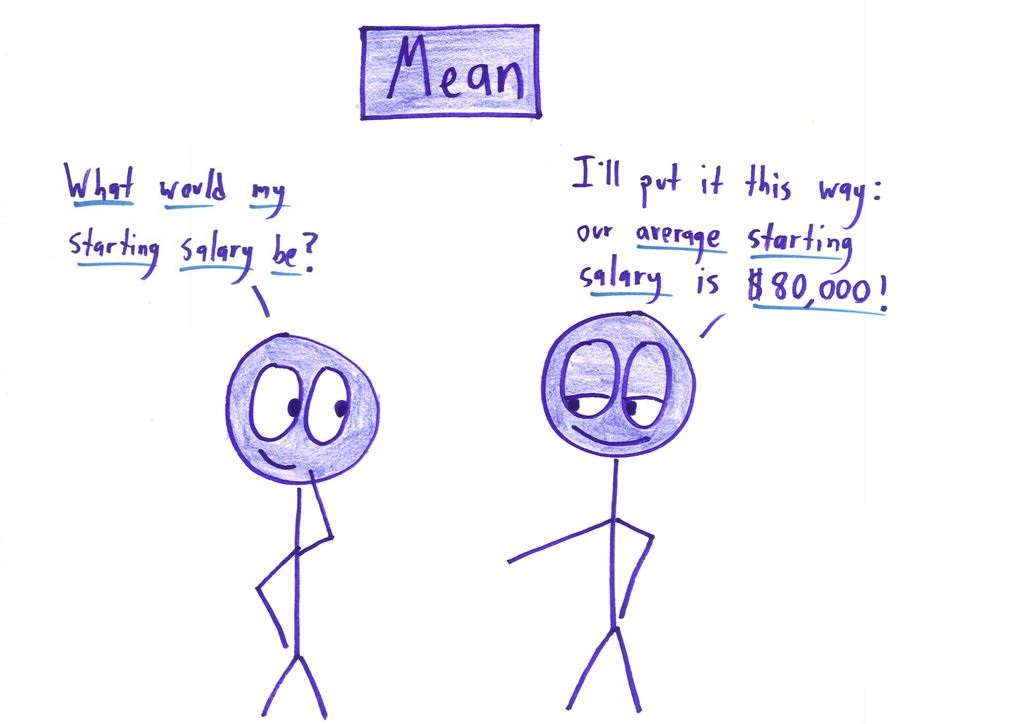

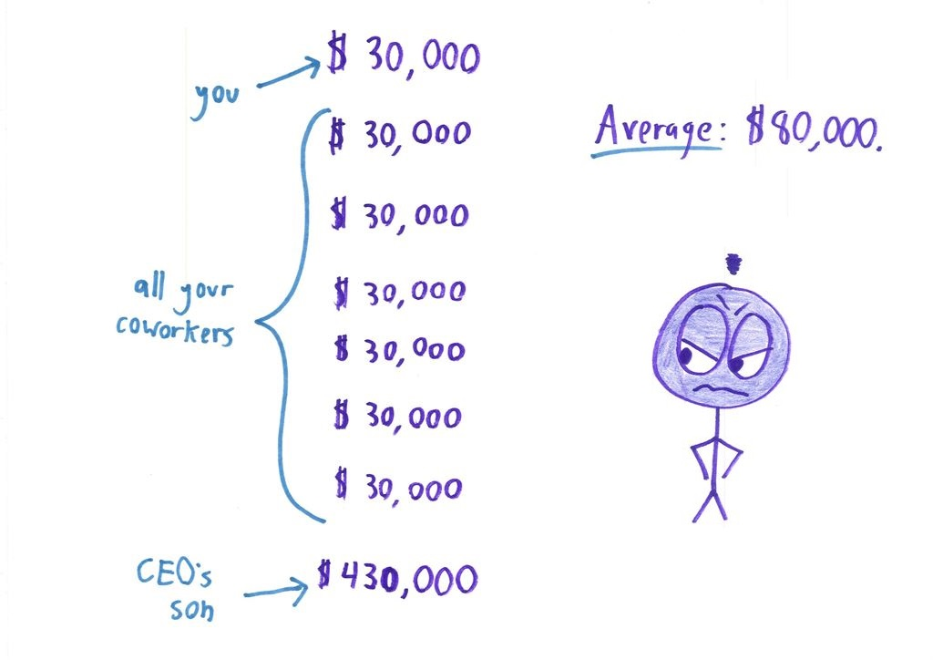

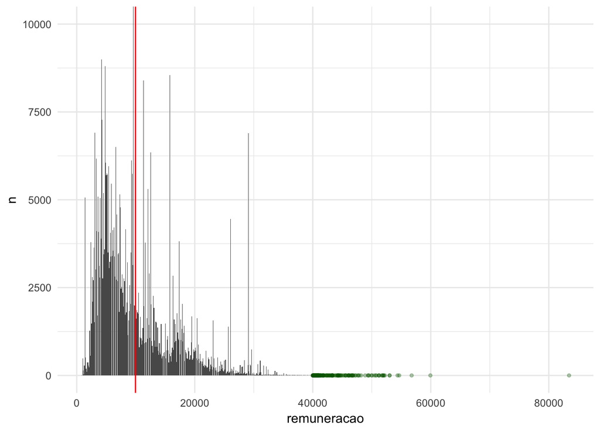

```r
subset_salarios %>%
  mutate(remuneracao = round(REMUNERACAO_REAIS, -2)) %>% # Arredonda para centenas
  count(remuneracao) %>%
  ggplot( aes(x = remuneracao, y = n)) +
  geom_col() +
  geom_vline(xintercept = mean(subset_salarios$REMUNERACAO_REAIS), color="red", size=0.5) +
  geom_point(data = filter(subset_salarios, REMUNERACAO_REAIS > 40000 ), mapping = aes(x=REMUNERACAO_REAIS), inherit.aes = FALSE, y=0, color="darkgreen", size=1, alpha = 0.3) +
  coord_cartesian(ylim = c(0, 10000)) +
  theme_minimal()
```

> > ATIVIDADE

Utilizando a função `year`, adicione ao dataset o Ano de Ingresso. A partir desta nova variável, determine o tempo médio de trabalho dos servidores, em nível nacional e por UF. Utilizar a data do campo `DATA_DIPLOMA_INGRESSO_SERVICOPUBLICO`. Nos dois casos, utilizar a combinação das funções `summarise` e `mean`.

Por fim, determine a média salarial por ano de ingresso.

```r
print("Atividade")
```

```
## [1] "Atividade"
```

```r
## Modificar o Dataset para criação de nova variável

## Determine o tempo médio de trabalho em anos, em nível nacional

## Determine o tempo médio de trabalho em anos, por UF

## Determine a média salarial por ano de ingresso
```

> > FIM DA ATIVIDADE

### Mediana

A mediana é o elemento central do conjunto (**ordenado**) de valores de uma variável.

- A figura do elemento central só existe quando o número de observações é ímpar!
- Quando o tamanho for par, o elemento central por definicão será a média entre os dois valores mais ao centro. Algumas variações assumem o menor dentre os dois valores, ou o maior dentre os dois valores.

Em R:

```r
median(x, na.rm = FALSE, ...)
```

### Exemplos com salário.

Mediana dos salários:

```r
median( subset_salarios$REMUNERACAO_REAIS )
```

```
## [1] 8214.58
```

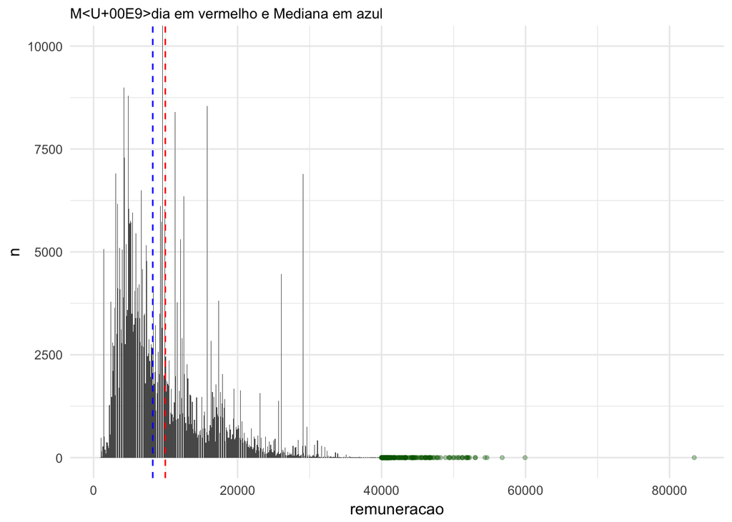

```r
subset_salarios %>%
  mutate(remuneracao = round(REMUNERACAO_REAIS, -2)) %>% # Arredonda para centenas
  count(remuneracao) %>%
  ggplot( aes(x = remuneracao, y = n)) +
  geom_col() +
  geom_vline(xintercept = mean(subset_salarios$REMUNERACAO_REAIS), color="red", size=0.5, linetype="dashed") +
  geom_vline(xintercept = median(subset_salarios$REMUNERACAO_REAIS), color="blue", size=0.5, linetype="dashed") +
  geom_point(data = filter(subset_salarios, REMUNERACAO_REAIS > 40000 ), mapping = aes(x=REMUNERACAO_REAIS), inherit.aes = FALSE, y=0, color="darkgreen", size=1, alpha = 0.3) +
  coord_cartesian(ylim = c(0, 10000)) +
  labs(subtitle = "Média em vermelho e Mediana em azul") +
  theme_minimal()
```

> > ATIVIDADE

**Atividade I**

Crie um novo dataset contendo a média e a mediana do salário por UF. Adicione uma nova variável determinando, para cada UF, se a média é maior ou menor que a mediana. Ao final, exiba a quantidade de UFs onde a mediana foi maior que a média.

```r
print("Atividade")
```

```
## [1] "Atividade"
```

```r
## Código aqui
```

**Atividade II**

Qual sua justificativa para a quantidade de casos onde a mediana foi maior que a média? Dica: Observe o gráfico que mostra a média e a mediana. Há cauda longa? Em qual direção?

`SUA RESPOSTA AQUI`

> > FIM DA ATIVIDADE

#### O que a Mediana *não* nos diz?

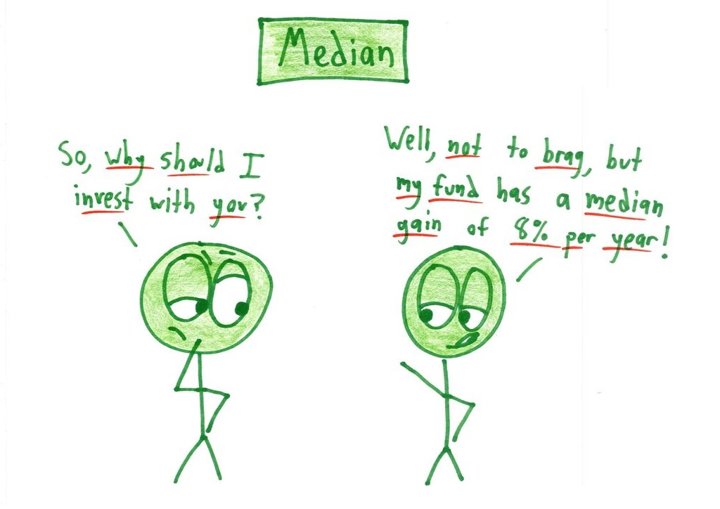

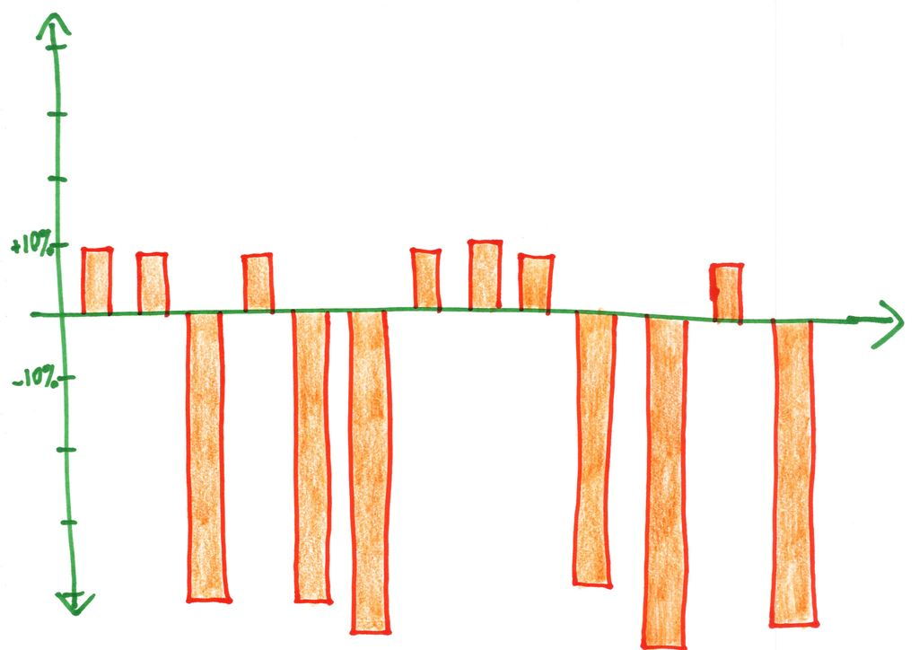

## Medidas de Variabilidade

Variabilidade Dispersão:

Além de saber o elemento típico do conjunto, é importante conhecer o quanto os valores se aproximam deste elemento típico, ou se estão espalhados/distribuídos em posições distantes do elemento central.

A medida de dispersão mais utilizada com Média Aritmética é o Desvio Padrão.

Já em relação à Mediana, tanto o Desvio Absoluto da Mediana quanto o Intervalo Interquartil são bastante utilizados. Nesta aula utilizaremos o Desvio Absoludo da Mediana.

### Medidas baseadas na Média

O principal conceito para entendimento do Desvio Padrão está relacionado ao cálculo da média em si.

Como vimos anteriormente, a soma dos resíduos é zero. Ao tentar sumarizar as distâncias dos valores em relação à média perdemos a própria noção de distância. O cálculo do Desvio Padrão utiliza o conceito de Variância para contornar este problema.

#### Variância

A variância utiliza o quadrado do resíduo para eliminar o sinal negativo. Além do efeito de transformar todos resíduos em valores positivos, o uso do quadrado possui propriedades que facilitam os cálculos de otimizações (a derivada do quadrado é de fácil aplicação).

$$Variancia = s^{2} = \frac{1}{n-1} \times \sum_{i=1}^{n}(x_{i} - \overline{x})^{2}$$

`Notar que a variância é indefinida para amostra de tamanho 1`

Em R:

```r
var(x, y = NULL, na.rm = FALSE, use)
```

```r
var(subset_salarios$REMUNERACAO_REAIS)
```

```
## [1] 43280759
```

Ao elevar os resíduos ao quadrado estamos também modificando a unidade de medida do resíduo. Enquanto subtraímos a média da observação, como no exemplo dos salários, temos o resíduo na mesma unidade de medida (R$ no nosso caso). Ao calcular a variância, passamos para uma unidade de medida irreal, que seria algo como $R \$ ^{2}$

#### Desvio padrão

O desvio padrão é definido pela raíz quadrada da variância:

$$s = \sqrt{Variancia}$$
em R:

```r
sd(x, na.rm = FALSE)
```

```r
sd( subset_salarios$REMUNERACAO_REAIS )
```

```
## [1] 6578.811
```

Ao aplicar a raíz quadrada, retornamos para a unidade de medida original, que é em R$. Temos então um desvio padrão de R$ 6578,81. Ao comparar com a média, que é de R$ 9954,77, observamos que um desvio corresponde a 66% da média. Não há uma regra geral para intepretação desta proporção, mas vamos considerar que temos uma grande dispersão de valores em torno da média. Essa medida é chamada de **Coeficiente de Variação**, e tem a característica de ser independente de unidade de medida.

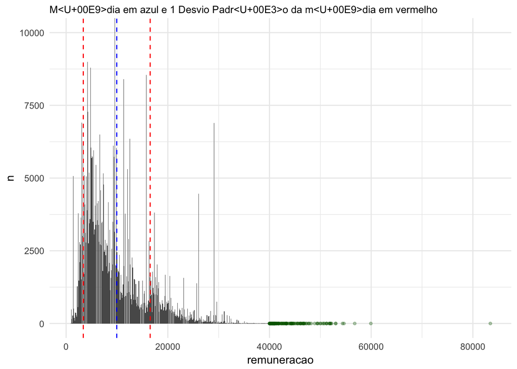

```r
subset_salarios %>%
  mutate(remuneracao = round(REMUNERACAO_REAIS, -2)) %>% # Arredonda para centenas
  count(remuneracao) %>%
  ggplot( aes(x = remuneracao, y = n)) +
  geom_col() +
  geom_vline(xintercept = mean(subset_salarios$REMUNERACAO_REAIS) - sd(subset_salarios$REMUNERACAO_REAIS), color="red", size=0.5, linetype="dashed") +
  geom_vline(xintercept = mean(subset_salarios$REMUNERACAO_REAIS) + sd(subset_salarios$REMUNERACAO_REAIS), color="red", size=0.5, linetype="dashed") +
  geom_vline(xintercept = mean(subset_salarios$REMUNERACAO_REAIS), color="blue", size=0.5, linetype="dashed") +
  geom_point(data = filter(subset_salarios, REMUNERACAO_REAIS > 40000 ), mapping = aes(x=REMUNERACAO_REAIS), inherit.aes = FALSE, y=0, color="darkgreen", size=1, alpha = 0.3) +
  coord_cartesian(ylim = c(0, 10000)) +
  labs(subtitle = "Média em azul e 1 Desvio Padrão da média em vermelho") +
  theme_minimal()
```

> > ATIVIDADE

**Atividade I**

A [Inequalidade de Chebyshev](https://en.wikipedia.org/wiki/Standard_deviation#Chebyshev's_inequality) afirma que, para distribuições de probabilidade onde o Desvio Padrão é definido, 2 Desvios Padrão da média devem absorver pelo menos 75% do tamanho da amostra.

Verifique a validade deste teorema com os valores calculados.

```r
print("Atividade")
```

```
## [1] "Atividade"
```

```r
## Código aqui
```

**Atividade II**

No dataset de salários temos os diferentes cargos ocupados pelos servidores públicos federais. Liste os 10 cargos de **menor coeficiente de variação** cujo cargo tenha mais que 100 servidores públicos. A lista deve conter, além do cargo e Coeficiente de Variação, a quantidade de servidores, o menor salário, o maior salário, o salário médio e o desvio padrão.

```r
print("Atividade")
```

```
## [1] "Atividade"
```

```r
## Código aqui
```

**Atividade III**

Repita a Atividade II, mas listando aqueles com **maior coeficiente de variação**.

```r
print("Atividade")
```

```
## [1] "Atividade"
```

```r
## Código aqui
```

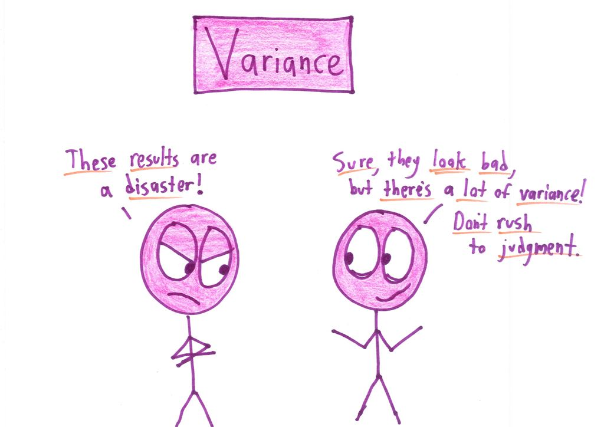

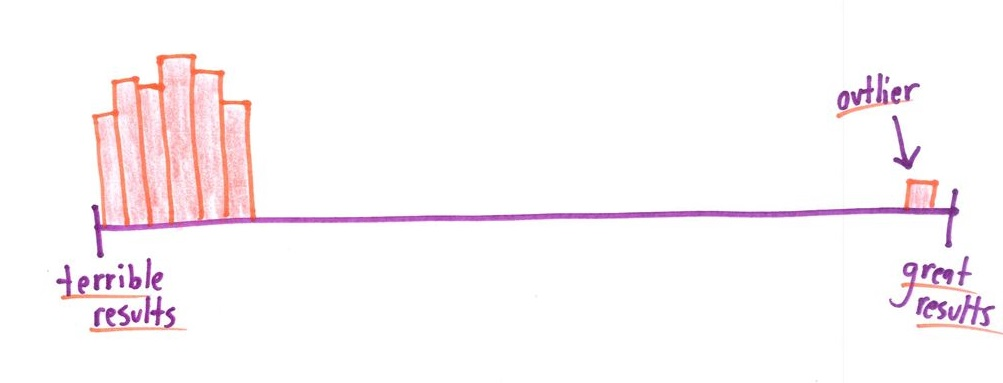

> > FIM DA ATIVIDADE

### Medidas baseadas na Mediana

Vimos, nas medidas de Tendência Central, que a Mediana é mais robusta que a média na presença de *Outliers*

Da mesma forma, as medidas de dispersão baseadas na mediana também não sofrem influência de valores extremos.

#### Desvio absoluto da mediana

O Desvio Absoluto da Mediana é definido como a mediana dos resíduos absolutos:

No R:

```r
(dam_salario <- median( abs( subset_salarios$REMUNERACAO_REAIS - median( subset_salarios$REMUNERACAO_REAIS ))))
```

```
## [1] 3655.19
```

Lembrando que a mediana é de:

```r
(md_salario <- median( subset_salarios$REMUNERACAO_REAIS ))
```

```
## [1] 8214.58
```

O desvio absoluto da mediana corresponde a

```r
dam_salario / md_salario
```

```
## [1] 0.4449637
```

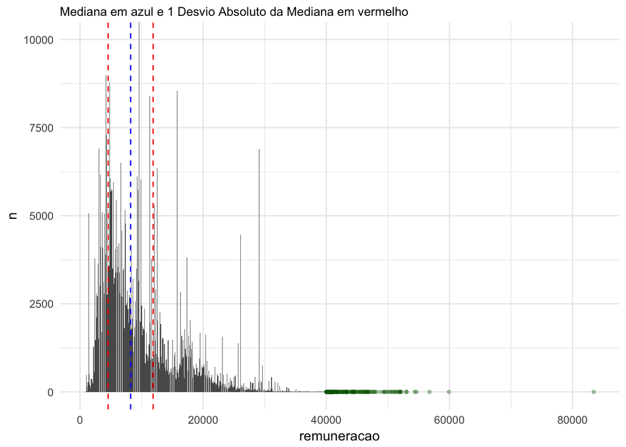

```r
subset_salarios %>%
  mutate(remuneracao = round(REMUNERACAO_REAIS, -2)) %>% # Arredonda para centenas
  count(remuneracao) %>%
  ggplot( aes(x = remuneracao, y = n)) +
  geom_col() +
  geom_vline(xintercept = md_salario - dam_salario, color="red", size=0.5, linetype="dashed") +
  geom_vline(xintercept = md_salario + dam_salario, color="red", size=0.5, linetype="dashed") +
  geom_vline(xintercept = md_salario, color="blue", size=0.5, linetype="dashed") +
  geom_point(data = filter(subset_salarios, REMUNERACAO_REAIS > 40000 ), mapping = aes(x=REMUNERACAO_REAIS), inherit.aes = FALSE, y=0, color="darkgreen", size=1, alpha = 0.3) +
  coord_cartesian(ylim = c(0, 10000)) +
  labs(subtitle = "Mediana em azul e 1 Desvio Absoluto da Mediana em vermelho") +
  theme_minimal()
```